# Example Nutpie GLMM

James Foster

2026-05-27

# Details

**DESCRIPTION**

Simulate population of individual-level data and fit Bayesian GLMMs using different software.

**INPUTS**

(None)

**OUTPUTS**

Model estimates.

**REFERENCES**

- Stan Development Team (2025). `RStan`: the `R` interface to `Stan`. R package version 2.32.7. https://mc-stan.org/.
- Gabry J, Češnovar R, Johnson A, Bronder S (2025). `cmdstanr`: R Interface to `CmdStan`. R package version 0.9.0.9000, commit 9fcbbd0695480500a879a8d0e226f7e8ec564d36, https://github.com/stan-dev/cmdstanr.
- Bürkner P-C (2021). Bayesian Item Response Modeling in `R` with `brms` and Stan. *Journal of Statistical Software*, 100(5), 1-54. doi:10.18637/jss.v100.i05
- Abril-Pla, O., Andreani, V., Carroll, C., Dong, L., Fonnesbeck, C. J., Kochurov, M., Kumar, R., Lao, J., Luhmann, C. C., Martin, O. A., et al. (2023). `PyMC`: a modern, and comprehensive probabilistic programming framework in Python. *PeerJ Computer Science* 9, e1516.
- Capretto, T., Piho, C., Kumar, R., Westfall, J., Yarkoni, T., & Martin, O.
  2022. `Bambi`: A simple interface for fitting Bayesian linear models in Python. *Journal of Statistical Software* 103(15), 1-29. doi:10.18637/jss.v103.i15
- Seyboldt, A., Carlson, E. L., & Carpenter, B. (2026). Preconditioning Hamiltonian Monte Carlo by minimizing Fisher Divergence. *arXiv* preprint arXiv:2603.18845.

# Motivation

Bayesian modelling represents a flexible and robust aproach to statistical modelling. Multiple software interfaces make it possible for the user to define models at a high level of abstraction, that can then be converted to more explicit code that runs efficiently within a Hamiltonian Markov-chain Monte-Carlo (MCMC) procedure using a No U-Turns Sampler (NUTS) on various operating systems.

In `R` the `brms` package allows users to define models that can then be run as `C++` executables by `rstan` (default) or `cmdstanr` (faster). In `Python` the `Bambi` package performs the same role for generating `PyMC` models, which rely on `numpyro` and `JAX` for sampling. `Nutpie` executes sampling via the extremely efficient `Rust` programming language, and can be used to sample (most) models written in `PyMC` or `Stan`. It also uses a very stable Hamiltonian MCMC algorithm (Seyboldt *et al*.), which seems to improve chain convergence and reduce the rate of divergent transitions; both of which reduce the reliability of model estimates.

# Set up workspace

To make use of `Python` via `R`, make sure that `reticulate`, `posterior` and `bayesplot`, are installed, and (on Windows) that you have installed the latest version of [Rtools](https://cran.r-project.org/bin/windows/Rtools/). Here we first set up a `reticulate` Python environment with the appropriate versions of each package, then load reticulate to ensure that those packages are available. We then load the packages required for `brms` models: `brms`, `rstan` and `cmdstanr`.

```r
p312=reticulate::install_python(version = '3.12')
```

```
## + '/Users/jamesfoster/Library/Application Support/r-reticulate/pyenv/bin/pyenv' update
```

```
## + '/Users/jamesfoster/Library/Application Support/r-reticulate/pyenv/bin/pyenv' install --skip-existing 3.12
```

```r
reticulate::virtualenv_create(
  envname = "GLMM-env",
  python = p312)
```

```
## virtualenv: GLMM-env
```

```r
reticulate::py_install(
  envname = "GLMM-env",
  packages =
            c("numpy>=1.26.4,<2.0.0",
              "pandas==2.2.2",
              "scipy==1.13.1",
              "arviz==0.19.0",
              "bambi==0.14.0",
              "pymc==5.16.2",
              "matplotlib==3.8.4",
              "formulae==0.5.4",
              "numba>=0.59.1,<=0.60.0",
              "nutpie",
              "bridgestan>=2.4.0,<3.0.0",
              "netcdf4>=1.6.5,<1.7.0",
              "h5py>=3.10.0,<4.0.0")
            )
```

```
## Using virtual environment 'GLMM-env' ...
```

```
## + /Users/jamesfoster/.virtualenvs/GLMM-env/bin/python -m pip install --upgrade --no-user 'numpy>=1.26.4,<2.0.0' 'pandas==2.2.2' 'scipy==1.13.1' 'arviz==0.19.0' 'bambi==0.14.0' 'pymc==5.16.2' 'matplotlib==3.8.4' 'formulae==0.5.4' 'numba>=0.59.1,<=0.60.0' nutpie 'bridgestan>=2.4.0,<3.0.0' 'netcdf4>…
```

```r
require(reticulate) #run python from R
use_virtualenv("GLMM-env",
               required = TRUE)
reticulate::py_config()
```

```
## python:         /Users/jamesfoster/.virtualenvs/GLMM-env/bin/python
## libpython:      /Users/jamesfoster/.pyenv/versions/3.11.15/lib/libpython3.11.dylib
## pythonhome:     /Users/jamesfoster/.virtualenvs/GLMM-env:/Users/jamesfoster/.virtualenvs/GLMM-env
## version:        3.11.15 (main, May  9 2026, 21:17:09) [Clang 15.0.0 (clang-1500.3.9.4)]
## numpy:          /Users/jamesfoster/.virtualenvs/GLMM-env/lib/python3.11/site-packages/numpy
## numpy_version:  1.26.4
##
## NOTE: Python version was forced by use_python() function
```

```r
#process and plot MCMC data
require(posterior)
require(bayesplot)
options(posterior.num_args = list(sigfig = 3))#for ease of reading
# packages for Bayesian regression in R
require(rstan)
require(cmdstanr)
require(brms)
## Import the nutpie and arviz pacakges into R
nutpie = import("nutpie")
az = import("arviz")
```

# Simuluate some data

## Simulate data from a random binomial

```r
set.seed(17070523)#seed the random number generator with Linnaeus' birthday


# . Set up simulation parameters ------------------------------------------

#Experimental variables
n_animals = 10# number of individuals
n_levels = 7# number of stimulus levels per individual
n_types = 2# number of stimulus types
replicates = 20#number of replicates of each condition

#starting parameters
pop_mean = 5.00#population mean
pop_sd = 1.00#population standard deviation
slope_mean = 3.00#population slope
slope_sd = 1.03#population slope standard deviation
type_mean = 2.50# effect of stimulus type 2 on average response
type_slope = 3.5# effect of type 2 on response to stimulus intensity
type_animal_sd = 0.55# sd of effect of animal on effect of type 2
extra_error_sd = 0.10#small source of unaccounted error


# . Set up experimental design --------------------------------------------

#Experiment design
animal = rep(x = 1:n_animals, # each animal has a number and experiences each level
             times = n_levels)
animal = sort(animal)# vector of animal numbers organised in order
animal = rep(x = animal, # each animal and level also includes each type
             times = n_types)
stimulus = rep(x = 1:n_levels - 1,# each stimulus has a number and repeats for each animal
               times = n_animals)
stimulus = rep(x = stimulus, # repeat stimulus for each type
               times = n_types)
stype = rep(x = 1:n_types, # each stimulus type for each animal and number
            times = n_animals * n_levels)
stype = sort(stype) # arrange in order

#replicate each observation
animal = rep(x = animal,
             times = replicates)
stimulus = rep(x = stimulus,
               times = replicates)
stype = rep(x = stype,
            times = replicates)

#baseline bias (response when stimulus = 0 and type = 1)
base_bias_animal = rnorm(n = n_animals,
                         mean  = pop_mean,
                         sd = pop_sd)
#response increase with each stimulus level
slope_animal = rnorm(n = n_animals,
                     mean = slope_mean,
                     sd = slope_sd)
#response to type 2
type_animal = rnorm(n = n_animals,
                    mean = 1.0, # on average, no random effect
                    sd = type_animal_sd)

# . Generate simulated data -----------------------------------------------

#Make an empty vector
response_y = rep(x = NA,
                 length = n_animals * n_levels * n_types * replicates)
#Loop through experiment design and generate theoretical response
for (ii in 1:length(response_y))
{
  #each data point is generated from the animal's intercept
  #plus the effect of stimulus type
  #plus the animal's response (slope) to changing stimulus level
  #scaled by the effect of different stimlus types
  #plus a small additional source or error
  response_y[ii] = base_bias_animal[animal[ii]] +
    (stype[ii] - 1) * type_mean +
    (slope_animal[animal[ii]] +
       (stype[ii] - 1) * type_slope * type_animal[animal[ii]]) * stimulus[ii] +
    rnorm(n = 1,
          mean = 0,
          sd = extra_error_sd)
}
#convert to binomial
correct_incorrect = rbinom(n = length(response_y),
                           size = 1,
                           prob = plogis(q = response_y - mean(response_y)) )


# Combine this into a single data.frame format object,
# with the experimental design and the measured response data
sim_data = data.frame(
  correct_incorrect = correct_incorrect,
  animal = LETTERS[animal],
  #animal names will now be capital letters
  stimulus = stimulus + 0.001,
  type = factor(stype,
                labels = c('alpha',
                           'beta'))
)
#Inspect data
head(sim_data)
```

```
##   correct_incorrect animal stimulus  type
## 1                 0      A    0.001 alpha
## 2                 0      A    1.001 alpha
## 3                 0      A    2.001 alpha
## 4                 1      A    3.001 alpha
## 5                 1      A    4.001 alpha
## 6                 1      A    5.001 alpha
```

## Plot aggregates from the simulated data

```r
dta = sim_data
#Set up plot colours
#on Rstudio these are distinct
clz = sapply(length(unique(dta$animal)),
             colorRampPalette(c(
               'red', 'blue', 'cyan4', 'magenta4', 'orange'
             )))
clz = sample(clz)#Randomise order?

#general overview
#aggragate the proportion correct for each animal
agg = aggregate(correct_incorrect~
                   stimulus * type * animal,
                 data = dta,
                FUN = mean)
#inspect the aggregate values
head(agg)
```

```
##   stimulus  type animal correct_incorrect
## 1    0.001 alpha      A              0.00
## 2    1.001 alpha      A              0.00
## 3    2.001 alpha      A              0.00
## 4    3.001 alpha      A              0.65
## 5    4.001 alpha      A              1.00
## 6    5.001 alpha      A              1.00
```

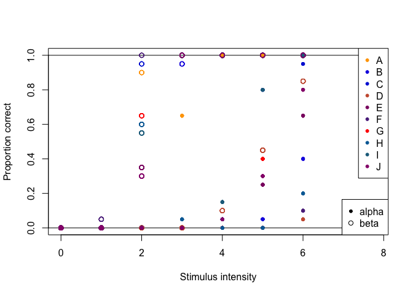

```r
# open an empty plot
plot(
  NULL,
  xlab = 'Stimulus intensity',
  ylab = 'Proportion correct',
  xlim = range(stimulus) * c(0.7, 1.3),
  ylim = c(0,1),
)
abline(h = c(0,1))
for (aa in agg$animal)
  with(subset(agg, animal == aa),
       #find the subset of the data with this animal
       {
         #Run code using this data as an environment
         points(
           x = stimulus,
           y = correct_incorrect,
           col = clz[which(LETTERS %in% aa)],
           #colour for this animal
           pch = c(20, 21)[1 + type %in% levels(type)[2]]
           # a dot, filled or open
         )
       })
legend(
  x = 'topright',
  legend = unique(agg$animal),
  col = clz,
  pch = 20
)
legend(x = 'bottomright',
       legend = unique(agg$type),
       pch = c(20, 21))
```

# Set up BRMS model

In this model, the correct choices can be predicted from the stimulus intensity, stimulus types and their interaction, as well as individual differences between each animal and their responses to each condition.

```r
frm_brms = bf(correct_incorrect ~
                  stimulus * type +
                  (1 + stimulus * type | animal)
              )
```

We set some default priors with moderate information. On the `logit` scale a change in log-odds of 1.0 corresponds to a large change in the probability of an event.

```r
pr_brms = prior("normal(0,1.0)", class = 'b') +
            prior("student_t(3,0,1.0)", class = 'sd')
```

# Run BRMS with rstan

```r
system.time({
  mod_rstan = brm(formula = frm_brms,
                  data = dta,
                  prior = pr_brms,
                  family = bernoulli(link = 'logit'),
                  silent = 2,#print only critical messages
                  refresh = 0,
                  chains = 4,
                  cores = 4,#run each chain on a separate CPU
                  iter = 2000,#2000 iterations
                  warmup = 1000,#use the first 1000 to tune the sampler
                  backend = 'rstan'
                  )
})
```

```
## Trying to compile a simple C file
```

[output not shown]

```
##    user  system elapsed
## 952.699   5.964 296.238
```

```r
summary(mod_rstan)
```

```
##  Family: bernoulli
##   Links: mu = logit
## Formula: correct_incorrect ~ stimulus * type + (1 + stimulus * type | animal)
##    Data: dta (Number of observations: 2800)
##   Draws: 4 chains, each with iter = 2000; warmup = 1000; thin = 1;
##          total post-warmup draws = 4000
##
## Multilevel Hyperparameters:
## ~animal (Number of levels: 10)
##                                  Estimate Est.Error l-95% CI u-95% CI Rhat
## sd(Intercept)                        0.72      0.60     0.02     2.22 1.00
## sd(stimulus)                         0.95      0.29     0.54     1.65 1.00
## sd(typebeta)                         0.80      0.64     0.03     2.45 1.00
## sd(stimulus:typebeta)                1.74      0.59     0.89     3.16 1.00
## cor(Intercept,stimulus)             -0.06      0.44    -0.82     0.79 1.00
## cor(Intercept,typebeta)             -0.05      0.44    -0.83     0.80 1.00
## cor(stimulus,typebeta)              -0.09      0.44    -0.84     0.77 1.00
## cor(Intercept,stimulus:typebeta)    -0.07      0.44    -0.83     0.78 1.00
## cor(stimulus,stimulus:typebeta)      0.04      0.30    -0.52     0.62 1.00
## cor(typebeta,stimulus:typebeta)      0.04      0.43    -0.76     0.80 1.00
##                                  Bulk_ESS Tail_ESS
## sd(Intercept)                        2733     1574
## sd(stimulus)                         1792     2668
## sd(typebeta)                         3139     2444
## sd(stimulus:typebeta)                1773     2856
## cor(Intercept,stimulus)               659     1690
## cor(Intercept,typebeta)              4384     2781
## cor(stimulus,typebeta)               5013     2814
## cor(Intercept,stimulus:typebeta)      644     1821
## cor(stimulus,stimulus:typebeta)      3038     2624
## cor(typebeta,stimulus:typebeta)      1322     2345
##
## Regression Coefficients:
##                   Estimate Est.Error l-95% CI u-95% CI Rhat Bulk_ESS Tail_ESS
## Intercept           -13.00      0.98   -14.95   -11.06 1.00     4262     3153
## stimulus              2.32      0.35     1.65     3.00 1.00     1920     2230
## typebeta              0.82      0.84    -0.83     2.40 1.00     5917     2822
## stimulus:typebeta     2.82      0.58     1.61     3.89 1.00     3181     2520
##
## Draws were sampled using sampling(NUTS). For each parameter, Bulk_ESS
## and Tail_ESS are effective sample size measures, and Rhat is the potential
## scale reduction factor on split chains (at convergence, Rhat = 1).
```

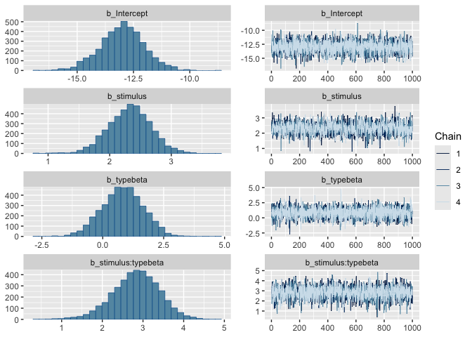

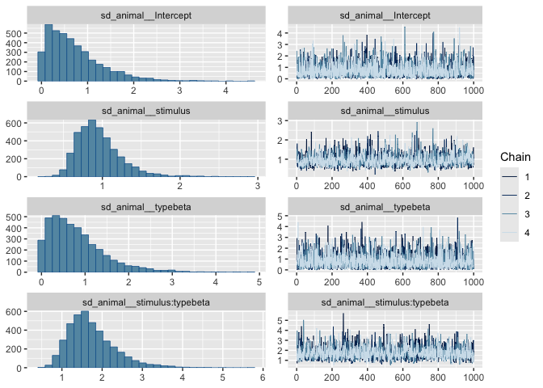

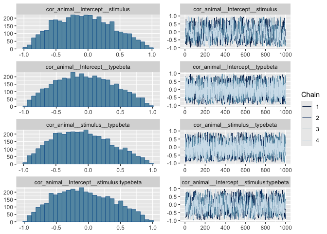

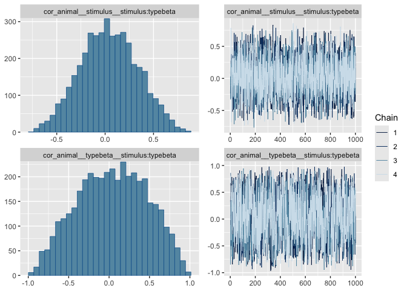

```r
plot(mod_rstan,
     nvar = 4,
     ask = FALSE)
```

Rhat <1.01 suggests all converged well.